# 人才画像数据分析 —— 使用手册

By 刘娟-产品研发部 [©北京智鼎优源管理咨询有限公司](http://talent.zhiding.com.cn)

02 六月, 2020

# Overview

### 人才画像是什么

> 人才画像是一种基于定性和定量分析得到的人才标准， 是能胜任关键岗位的人才原型， 是组织关键人群的虚拟代表。

**XX企业研发岗画像：**

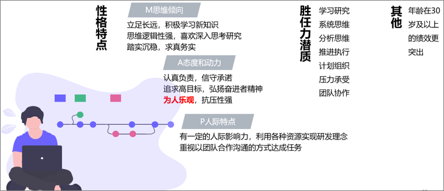

### 如何画像

一个完整的人才画像建立流程通常有4步：

1. 项目需求沟通与确认
2. 访谈与定性分析
3. 人才测评数据收集与分析
4. 画像与应用

其中第3、4步为**数据分析**和**模型验证**，可借助此分析平台来实现。

## Get started

在人才画像分析平台上，用户可以获得权限范围内项目的测评数据仅限MAP产品，包括性格维度原始十分和标准Z分数，胜任力标准十分和标准Z分数，这些数据可在各个模块内被选入相应的分析方法内使用，不同的方法会自动调取不同类型的分数（Z分或十分），也可以点击页面顶端下载原始数据将数据导出到本地以便进行其他分析或操作，导出文件格式为`.xlsx`。

除测评数据外，用户也可获得线上的人员信息，同时用户也可以导入线下人员信息到线上，从而使用外部拓展数据做分析。导入信息时，需先在项目人员设置页下载线下信息导入模板，务必按模板要求导入，否则会出现未知错误。

**用户如果本地中有其他测评产品的数据，也可一并导入平台分析**，但无法从线上直接获取。

准备好项目数据后，就可以进入数据分析阶段了……

在后文的说明中，将会使用一个仿真数据辅助演示各个分析模块的功能和结果

仿真数据：

| 性别 | 性别.重 | 学历 | 年龄分组 | 绩效等级 | 绩效分数 | 创新 | 数据导向 | 前瞻性 | 开放创新 | 沉着务实 | 责任心 | 沉着务实z | 开放创新z | 责任心z |
| --- | --- | --- | --- | --- | --- | --- | --- | --- | --- | --- | --- | --- | --- | --- |
| 男 | 女 | 本科 | 20岁及以下 | A | 98 | 7 | 5 | 6 | 4 | 9 | 10 | -0.80 | 0.4 | 0.1 |
| 男 | 女 | 硕士研究生 | 20~30岁 | C | 60 | 6 | 6 | 6 | 5 | 6 | 5 | 1.60 | 0.5 | 0.5 |
| 女 | 女 | 博士研究生 | 30岁以上 | B | 88 | 7 | 7 | 6 | 6 | 6 | 6 | 1.00 | -0.6 | -1.6 |
| 女 | 女 | 硕士研究生 | 20岁及以下 | B | 80 | 7 | 8 | 6 | 8 | 9 | 8 | 0.65 | 1.8 | 2.8 |
| 女 | 女 | 本科 | 20岁及以下 | A | 92 | 10 | 9 | 6 | 10 | 10 | 2 | -1.20 | 1.2 | 2.2 |
| 男 | 女 | 本科 | 20岁及以下 | A | 90 | 7 | 5 | 6 | 4 | 9 | 10 | -0.80 | 0.4 | 0.1 |
| 男 | 女 | 硕士研究生 | 20~30岁 | C | 70 | 6 | 6 | 6 | 5 | 6 | 5 | 1.60 | 0.5 | 0.5 |
| 女 | 女 | 博士研究生 | 30岁以上 | B | 84 | 7 | 7 | 6 | 6 | 6 | 6 | 1.00 | -0.6 | -1.6 |
| 女 | 女 | 硕士研究生 | 20岁及以下 | B | 83 | 7 | 8 | 6 | 8 | 9 | 8 | 0.65 | 1.8 | 2.8 |
| 女 | 女 | 本科 | 20岁及以下 | A | 91 | 10 | 9 | 6 | 10 | 10 | 2 | -1.20 | 1.2 | 2.2 |

注：每一行代表一条数据

## 数据分析

### 频数/百分比

当我们刚拿到一份数据时，第一时间往往是想看一下数据的全貌，常用的方法之一就是看一下各个变量内各类别的频数分布和占比，比如检查下性别比例、学历的情况、年龄的分布等等。

**学历**

此时需要在页面上点选`学历`标签，然后点击开始分析

|  | 本科 | 博士研究生 | 硕士研究生 |
| --- | --- | --- | --- |
| 人数 | 4 | 2 | 4 |
| 百分比 | 40 | 20 | 40 |

**性别**

点选`性别`标签

|  | 男 | 女 |
| --- | --- | --- |
| 人数 | 4 | 6 |
| 百分比 | 40 | 60 |

**创新**

也可查看性格维度或胜任力的分数分布，以`创新`为例

|  | 6 | 7 | 10 |
| --- | --- | --- | --- |
| 人数 | 2 | 6 | 2 |
| 百分比 | 20 | 60 | 20 |

### 描述分析

另一种概览数据全貌的方法是做均值的描述分析，仅适用于数值型的变量，比如性格分数、胜任力分数、绩效分数等。

在此分析方法下，当用户未选择分组变量时，输出结果为单变量的描述统计，当用户选择**1个**分组变量时，输出结果为某分数在该分组变量内各个类别上的**均值统计**，当用户选择**2个及以上**的分组变量时，输出结果为某分数在各分组变量内**交叉组合类别**上的均值统计。

因此，当用户希望了解**不同人群在某项分数上的均值差异**时，在此方法下选择相应的人群分组变量即可实现。而均值差异是否具有**统计学意义**，还需做T检验或回归分析等进一步统计检验分析

**开放创新**

点选`开放创新`标签,可得到`开放创新`的单变量描述统计结果

表格内的数值，从左往右依次是：最小值、1/4位数、中位数、均值、3/4位数、最大值

|  | Min. | 1st Qu. | Median | Mean | 3rd Qu. | Max. |
| --- | --- | --- | --- | --- | --- | --- |
| 开放创新 | 4 | 5 | 6 | 6.6 | 8 | 10 |

**创新、数据导向** （无分组）

可同时选择多个变量进入分析,点选`创新` `数据导向`标签

|  | Min. | 1st Qu. | Median | Mean | 3rd Qu. | Max. |
| --- | --- | --- | --- | --- | --- | --- |
| 创新 | 6 | 7 | 7 | 7.4 | 7 | 10 |
| 数据导向 | 5 | 6 | 7 | 7.0 | 8 | 9 |

**创新、数据导向 by 性别** （1个分组）

点选`创新` `数据导向`标签进入分析变量，点选`性别`标签进入分组变量

可以看到，输出结果为`创新` `数据导向`在`性别`的两个分组：男和女上的平均值

|  | 男 | 女 |
| --- | --- | --- |
| 创新 | 6.5 | 8.0 |
| 数据导向 | 5.5 | 8.0 |

**创新、数据导向 by 性别×绩效×学历** （3个分组）

点选`创新` `数据导向`标签进入分析变量，点选`性别` `绩效` `学历`标签进入分组变量

可以看到，输出结果为`创新` `数据导向`在`性别` * `绩效` * `学历`的交叉分组上的均值，3个分组变量共产生了5个交叉组别，以**group.1**的结果为例：

**性别为男、绩效为A，学历为本科**这样一批人在创新和数据导向上的均值分别为7和5

|  | group.1 | group.2 | group.3 | group.4 | group.5 |
| --- | --- | --- | --- | --- | --- |
| var.性别 | 男 | 女 | 女 | 女 | 男 |
| var.绩效等级 | A | A | B | B | C |
| var.学历 | 本科 | 本科 | 博士研究生 | 硕士研究生 | 硕士研究生 |
| 创新 | 7 | 10 | 7 | 7 | 6 |
| 数据导向 | 5 | 9 | 7 | 8 | 6 |

分析页面的所有结果表格可在本页面顶端点击下载分析数据导出`.xlsx`格式的文件到本地，用于绘图或进一步分析

**如用于绘制对比分析轮廓图：**

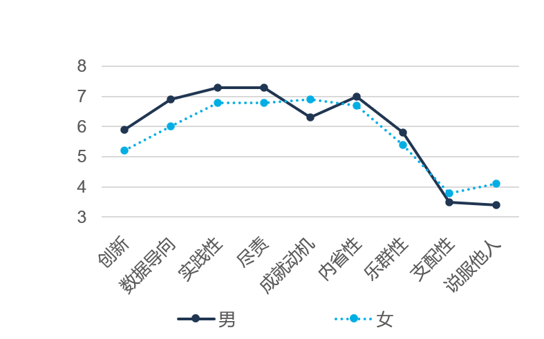

也可点击下载分析报告导出pdf版本到本地，以供后续查看和分析

### 交叉分析（卡方）

当我们希望能看到两个变量之间的交叉趋势且对该趋势做统计检验时，可选用交叉分析&卡方检验。结果输出有两个表格，一个是体现了2变量交叉趋势的列联表，另一个是对该列联表的卡方检验结果，通过卡方检验结果我们可以确认列联表中是否存在具有统计学意义的交叉趋势，如果卡方检验结果的P值大于**0.05**，则列联表内的趋势大概率是偶然发生的。

需要注意的是，选入分析的两个变量均不能为常数，即变量内所有人都是同一个数值或同一个字符，如仿真数据中**性别.重**变量。

**P值标准说明**

P<0.05,在0.05统计显著水平显著

P<0.01,在0.01统计显著水平显著

**学历 × 绩效等级**

点选`学历`进入行变量，点选`绩效等级`进入列变量

从列联统计表中，我们可以看到，本科学历人群的绩效等级均为A，博士研究生的绩效等级均为B，硕士研究生在B和C上各有2人。因此可以初步推测，本科学历人群的绩效要优于硕、博研究生，硕士研究生最差。 卡方检验结果的P值为0.0139958，达到了统计学显著标准，说明以上趋势并非偶然发生。

**列联统计表**

|  | A | B | C |
| --- | --- | --- | --- |
| 本科 | 4 | 0 | 0 |
| 博士研究生 | 0 | 2 | 0 |
| 硕士研究生 | 0 | 2 | 2 |
| 本科(%) | 100 | 0 | 0 |
| 博士研究生(%) | 0 | 100 | 0 |
| 硕士研究生(%) | 0 | 50 | 50 |

**卡方检验结果**

|  | 卡方值 | 自由度.df. | P值 |
| --- | --- | --- | --- |
| X-squared | 12.5 | 4 | 0.0139958 |

### 与常模的差异检验

在分析测评数据时，除了对比数据内部不同人群的差异外，也会和常模人群进行对比分析。因为大概率情况下，同一组织人群会具有一些共同的特征，比如互联网企业普遍在`创新`维度得分较高，而常模人群不一定如此。这些共同特点在组织内部比较是无法得到的，需要与常模人群进行比较才能提炼出来。

与常模的差异检验采用的是单一样本T检验方法，结果会输出T值、P值和效果量_d。如果P值大于**0.05**，则说明检验变量分数与常模人群不存在明显差异。

各常模版本人群的在性格维度的均值需联系产品研发部liuj@zhiding.com.cn获取  
各常模版本人群在胜任力潜质上的均值均为5.5

与常模人群的差异检验，仅支持线上测评数据，即性格维度和胜任力潜质。

**效果量_d（绝对值）指标说明**

Small: 0.2-0.5

Medium: 0.5-0.8

Large: >0.8

**开放创新、沉着务实**

点选`开放创新` `沉着务实`标签

可以看到，该数据与常模人群无明显差异

|  | t值 | p值 | 效果量_d |
| --- | --- | --- | --- |
| 沉着务实z | 0.7906 | 0.4495 | 0.25 |
| 开放创新z | 2.0871 | 0.0665 | 0.66 |

### 独立样本T检验

在描述分析中，我们可以通过指定分组变量，来观察某个测评分数在该变量内部各个类别上的均值差异。但这个均值差要多大才能有效说明真实问题呢？或者说要达到什么标准我们才能说不同类别的人之间的均值差异能推广到总体呢？当分组变量内的类别仅有2个时，如性别：男、女，以上问题便可以通过独立样本T检验回答。  
独立样本T检验的结果产出和与常模的差异检验形式一样，均有T值、P值和效果量_d，如果P值大于**0.05**，则说明检验变量在该分组变量不同人群上的均值不存在明显差异。

**0.05**和**0.01**的P值临界值是统计学统一的标准，但略微大于0.05也在一定程度上反映了结果的差异性，因此当P值小于0.1时，结果也是具有参考价值的。  
常模人群中，各种人口学变量在**最新版MAP**测评数据上的差异分析见MAP2.0常模与行业对标说明- 专业版

**开放创新、沉着务实 by 性别**

点选`开放创新` `沉着务实`标签进入检验变量，点选`性别`进入分组变量

可以看到，2个检验变量在性别上不具有显著性差异

|  | t值 | p值 | 效果量_d |
| --- | --- | --- | --- |
| 沉着务实z | 0.3252 | 0.7534 | 0.2099 |
| 开放创新z | -0.7659 | 0.4781 | -0.4944 |

### 回归分析

#### 一元回归分析

独立样本T检验适用于分组变量仅有2个类别的情境，当类别超过2个时，均值差异检验可使用一元回归分析来进行，此结果等价于单因素方差分析。

所谓一元回归，即自变量X（也称预测变量）仅有1个： Y = β<sub>0</sub> + β<sub>1</sub>X1 。X1（自变量）可为分类变量，也可以是数值变量。当X1为分类变量，Y为数值变量时，其模型检验结果与单因素方差分析和独立样本T检验具有等价性，当X1和Y均为数值变量时，此结果与皮尔逊相关分析结果具有等价性。

结果输出有两个表格，第一个是自变量的回归系数表格，另一个是模型的整体检验结果。

另外需要注意的是，回归分析的因变量Y仅支持选择数值变量。

**回归分析指标说明**

**回归系数表格**

自变量-（intercept）：为回归截距，其显著与否不重要

自变量-绩效分数：用户选入的自变量名称

回归系数：未标准化的回归系数，数值大小代表着其对因变量的影响程度

标准误：该回归系数估计的标准误差  
系数t检验的t值：回归系数t检验的t值，其是否有价值需看对应的P值

**P值：小于0.05则说明系数显著，此自变量有意义**

检验变量：用户选入的因变量名称

**模型检验表格**

r.squared: 当X与Y均为数值变量时，等价于皮尔逊相关系数的平方

adj.r.squared： 考虑了自变量个数和样本数量影响的R方，会小于R方

p.value： 当X与Y均为数值变量时，等价于皮尔逊相关系数的p值

**开放创新、沉着务实 ~ 绩效分数**

点选`开放创新` `沉着务实`标签进入Y（因变量），点选`绩效分数`进入X（自变量）

可以看到，绩效分数与开放创新之间无关联，P值为**0.956**，远大于0.05

绩效分数与沉着务实之间存在显著相关关系，P值为**0.005**，达到了显著水平，且模型检验结果的**P值为0.0045<0.05**，调整后R方（adj.r.squared）为0.613，说明此模型建立有效，自变量对因变量的解释程度为**61.3%**

**回归系数**

| 自变量 | 回归系数 | 标准误 | 系数t检验 | P值 | 检验变量 |
| --- | --- | --- | --- | --- | --- |
| (Intercept) | 0.788 | 2.249 | 0.350 | 0.735 | 开放创新z |
| 绩效分数 | -0.002 | 0.027 | -0.057 | 0.956 | 开放创新z |
| (Intercept) | 7.024 | 1.750 | 4.014 | 0.004 | 沉着务实z |
| 绩效分数 | -0.081 | 0.021 | -3.902 | 0.005 | 沉着务实z |

**模型检验**

| r.squared | adj.r.squared | p.value | AIC | BIC | 检验变量 |
| --- | --- | --- | --- | --- | --- |
| 0.0004122 | -0.1245363 | 0.9556071 | 30.13428 | 31.04204 | 开放创新z |
| 0.6556042 | 0.6125547 | 0.0045290 | 25.11675 | 26.02451 | 沉着务实z |

**开放创新、沉着务实 ~ 学历**

点选`开放创新` `沉着务实`标签进入Y（因变量），点选`学历`进入X（自变量）

可以看到，在学历为自变量的回归结果中，本科学历人群未出现在回归系数表中，这是由于此分析方法自动将本科学历人群将作为了**参照组**

在分析中我们可以这么说：学历为博士研究生的人群在沉着务实上均值要**大于**学历为本科（参照组）的人群，因为其回归系数为2，大于0，如果小于0，则说明其小于本科学历人群。同理可见硕士学历人群也一样高于参照组。

从模型检验表格中我们也可以看到，两个模型的**P值**均低于**0.05**，说明两个模型中的自变量均与因变量具有显著的相关关系，观察调整后R方（adj.r.squared）：第一个模型中自变量对因变量的解释度为**54.2%**，第二个模型中自变量对因变量的解释度为**88.1%**

**回归系数**

| 自变量 | 回归系数 | 标准误 | 系数t检验 | P值 | 检验变量 |
| --- | --- | --- | --- | --- | --- |
| (Intercept) | 0.800 | 0.288 | 2.773 | 0.028 | 开放创新z |
| 学历博士研究生 | -1.400 | 0.500 | -2.802 | 0.026 | 开放创新z |
| 学历硕士研究生 | 0.350 | 0.408 | 0.858 | 0.419 | 开放创新z |
| (Intercept) | -1.000 | 0.195 | -5.134 | 0.001 | 沉着务实z |
| 学历博士研究生 | 2.000 | 0.337 | 5.928 | 0.001 | 沉着务实z |
| 学历硕士研究生 | 2.125 | 0.275 | 7.714 | 0.000 | 沉着务实z |

**模型检验**

| r.squared | adj.r.squared | p.value | AIC | BIC | 检验变量 |
| --- | --- | --- | --- | --- | --- |
| 0.6439487 | 0.5422197 | 0.0269336 | 21.81160 | 23.02194 | 开放创新z |
| 0.9076087 | 0.8812112 | 0.0002397 | 13.95917 | 15.16951 | 沉着务实z |

#### 多元回归分析

一元回归分析是两个变量之间的分析，一个自变量和一个因变量。但很多时候，我们希望能看到多个自变量是如何同时对一个因变量起作用的，此时就需要用到多元回归分析方法。

所谓多元回归，即自变量X为多个的情境： Y = β<sub>0</sub> + β<sub>1</sub>X1 + β<sub>2</sub>X2 + β<sub>3</sub>X3 + ……，其中X可为分类变量也可为连续型变量。

多元回归结果的表格分析方式与一元回归线相似，指标说明参考一元回归模块内的即可。

**开放创新、沉着务实 ~ 绩效分数 + 学历**

点选`开放创新` `沉着务实`标签进入Y（因变量），点选`绩效分数` `学历`进入X（自变量）

可以看到，回归系数表格里，在一个检验变量下，有多个自变量的回归结果：绩效分数和各学历类别

绩效分数和学历对沉着务实的回归系数均达到了0.05显著水平，说明这两个自变量对因变量均具有显著影响。其中绩效分数对沉着务实有负向影响，本科人群均值低于硕博人群。

**回归系数**

| 自变量 | 回归系数 | 标准误 | 系数t检验 | P值 | 检验变量 |
| --- | --- | --- | --- | --- | --- |
| (Intercept) | -4.030 | 2.261 | -1.783 | 0.125 | 开放创新z |
| 绩效分数 | 0.052 | 0.024 | 2.148 | 0.075 | 开放创新z |
| 学历博士研究生 | -1.048 | 0.438 | -2.396 | 0.054 | 开放创新z |
| 学历硕士研究生 | 1.365 | 0.577 | 2.365 | 0.056 | 开放创新z |
| (Intercept) | 2.644 | 1.373 | 1.926 | 0.102 | 沉着务实z |
| 绩效分数 | -0.039 | 0.015 | -2.668 | 0.037 | 沉着务实z |
| 学历博士研究生 | 1.735 | 0.266 | 6.528 | 0.001 | 沉着务实z |
| 学历硕士研究生 | 1.359 | 0.351 | 3.875 | 0.008 | 沉着务实z |

**模型检验**

| r.squared | adj.r.squared | p.value | AIC | BIC | 检验变量 |
| --- | --- | --- | --- | --- | --- |
| 0.7987253 | 0.6980879 | 0.0164312 | 18.107561 | 19.620487 | 开放创新z |
| 0.9577468 | 0.9366202 | 0.0001624 | 8.135642 | 9.648567 | 沉着务实z |

# 数据编码

# 隐藏功能

**数据下载**

可通过平台上的下载原始数据功能，下载从成绩表中无法获得的全版（36项）胜任力分数，该分数包括标准十分和标准Z分数，如果项目使用的是老版MAP，胜任力个数可能不足36个。同时也可以获得性格维度的Z分数。

**旧数据的重新算分**

可通过平台上的重新算分功能，依据最新常模计算同一产品编号的胜任力分数、性格维度标准Z分数，此功能仅支持MAP-R，老版MAP的常模已停止更新。

**其他可能的数据分析**

可通过导入外部拓展数据的方式对其他可能的数据进行分析。  
**流程：**先选定项目、绑定相应人员，下载数据上传模板，在模板内添加自己想要分析的数据即可，此时项目人员可能不是你想关注的，但没关系，这里只是用他们做了一下“工具人”，只分析自己添加的数据就好。